# Muestreo para Digitalización E-14

Planificación de digitalización de formularios en Medellín (Comuna 1 vs. Comuna 14)

Mateo Campo - Stiven Saldarriaga - Santiago Vanegas - Sebastián Rodríguez

2026-05-29

## Contexto y Objetivo

Comparación electoral y diseño muestral para la **digitalización de formularios E-14** el próximo domingo.

Zona Norte (Comuna 1 - Popular)

- **Características:** Niveles bajos de ingresos y alta densidad de votantes.
- **Comportamiento:** Mayor abstencionismo histórico y fragmentación del voto.

Zona Sur (Comuna 14 - El Poblado)

- **Características:** Niveles de ingresos altos y menor densidad demográfica.
- **Comportamiento:** Alta participación y preferencia marcada por partidos tradicionales.

## Estrategia de Muestreo

Selección óptima de puestos de votación mediante **criterio de concentración (50%)**.

Proceso de Selección

1. **Agregación:** Consolidamos las mesas de votación por puesto físico.
2. **Ordenamiento:** Clasificamos puestos de mayor a menor volumen de votos.
3. **Selección:** Elegimos puestos hasta acumular el **50% de los votos** de cada comuna.

🎯 Meta de Digitalización

Optimizar el procesamiento de actas E-14 para el próximo domingo, cubriendo el **50% del censo electoral** con solo **7 puestos estratégicos**.

## Participación Electoral

Análisis de votos promedio por mesa para planificar la carga de digitalización.

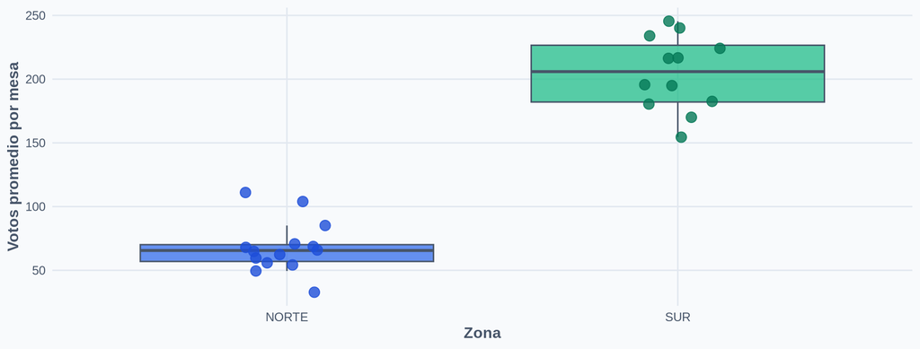

⚡ Implicaciones E-14

## Puestos Seleccionados

Los **7 puestos de votación** elegidos que concentran el 50% de la votación de ambas comunas.

| Zona | Puesto de Votación | Mesas a Procesar | Total Votos Históricos |
| --- | --- | --- | --- |
| NORTE | SEC.ESC.AGRIPINA MONTES DEL VALLE | 25 | 2775 |
| NORTE | SEC. ESC. MEDELLIN | 26 | 2699 |
| NORTE | SEC. ESC. DIVINA PROVIDENCIA | 36 | 2249 |
| NORTE | INST.EDUC. LA CANDELARIA | 50 | 3427 |
| SUR | COL.SANTA MARIA DEL ROSARIO | 32 | 7491 |
| SUR | COL.MARYMOUNT | 37 | 8886 |
| SUR | UNIVERSIDAD EAFIT | 47 | 10186 |

## Logística de Digitalización

📋 Asignación de Mesas por Integrante

Para procesar las **253 mesas** totales de la muestra de forma equitativa:

- **Mateo Campo:** 63 mesas (34 Norte, 29 Sur)
- **Stiven Saldarriaga:** 63 mesas (34 Norte, 29 Sur)
- **Santiago Vanegas:** 63 mesas (34 Norte, 29 Sur)
- **Sebastián Rodríguez:** 64 mesas (35 Norte, 29 Sur)

⚡ Resumen Operativo

- **Total de Puestos:** 7 puestos estratégicos.
- **Total de Mesas:** 253 formularios E-14 a procesar.
- **Meta de Cobertura:** 50% de la representación electoral de ambas comunas.
- **Carga de Trabajo:** ~63 mesas por integrante.